# Lecture 1 - CHI 2022 Course Transparent Practices for Quantitative Empirical Research

Chat Wacharamanotham

# **Purpose**

This R Notebook shows several strategies from frequentist statistics to analyze a dataset. They serve as examples of how to apply [Transparent Statistics Guiding Principles](https://transparentstats.github.io/guidelines/principles.html#guiding-principles).

```r
library(MASS)
library(ordinal)
library(emmeans)
library(tidyverse)
# remove spurious warning message from summarize(). For more info see `?summarize`
options(dplyr.summarise.inform = FALSE)
```

# **The dataset**

The dataset is from experiment 1 of “Blinded with Science or Informed by Charts? A Replication Study” [(Dragicevic & Jansen, 2018)](https://doi.org/10.1109/TVCG.2017.2744298)  
Study participants were shown a vignette of a report about drug effectiveness **with** vs. **without a chart**. The experiment is a between-subjects design. One of the dependent variables is a rating on how they believe in the effectiveness of the drug on a 9-point Likert-style item.

```r
dataset <-

  # read the file
  read_csv("data/blinded.csv",
           col_types = cols(
             experiment = col_integer(),
             condition = col_character(),
             effectiveness = col_integer())) %>%

  # select only experiment 1 (out of 4)
  filter(experiment == "1") %>%

  # ensure that the condition column has a `factor` data type (required for correct modelling)
  mutate(condition = factor(condition)) %>%

  # adding participant ID
  mutate(participant_id = str_c("P", str_pad(row_number(), 2, pad = "0"))) %>%

  # extract only three columns that are relevant for this example
  select(participant_id, condition, effectiveness)


# show the output of this code chunk
dataset
```

| participant_id | condition | effectiveness |
| --- | --- | --- |
| P01 | no_graph | 7 |
| P02 | graph | 6 |
| P03 | no_graph | 9 |
| P04 | no_graph | 4 |
| P05 | graph | 6 |
| P06 | no_graph | 7 |
| P07 | graph | 7 |
| P08 | no_graph | 7 |
| P09 | no_graph | 7 |
| P10 | graph | 6 |

[output cut: 113 more lines]

The order of the difference is controlled by the order of the factor level of the `condition` column in the dataset. By default, the order is alphabetical:

```r
levels(dataset$condition)
```

```
[1] "graph"    "no_graph"
```

Therefore, in this dataset, all statistical estimates of the difference below will be in the following form:

> `graph` - `no_graph`

This order happens to make sense because `no_graph` condition is considered the baseline. If you need to change the order of a factor in your dataset, check [the section “Modifying factor order” in R4DS book](https://r4ds.had.co.nz/factors.html#modifying-factor-order).

## Data overview

We show an overview of the data in a table and chart below:

```r
dataset %>%
  group_by(condition, effectiveness) %>%
  summarise(N = n()) %>%
  ungroup() %>%
  pivot_wider(names_from = condition, values_from = N) %>%
  arrange(effectiveness)
```

| effectiveness | graph | no_graph |
| --- | --- | --- |
| 1 | 1 | NA |
| 3 | NA | 1 |
| 4 | 3 | 4 |
| 5 | 8 | 5 |
| 6 | 14 | 12 |
| 7 | 21 | 25 |
| 8 | 9 | 7 |
| 9 | 5 | 8 |

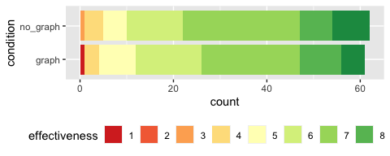

```r
p_condition <-
  dataset %>%

  # reverse the factor level for a correct plot order
  mutate(effectiveness = fct_rev(factor(effectiveness, levels = 1:9))) %>%

  # stacked bar plot
  ggplot(aes(x = condition, fill = effectiveness)) +
  geom_bar(position = "stack", stat="count") +

  # color scale from red (low) to yellow (middle) to green (high)
  scale_fill_brewer(palette="RdYlGn", drop = FALSE, direction = -1) +

  # horizontal plot
  coord_flip() +

  # legend
  guides(fill = guide_legend(reverse = TRUE, nrow = 1)) +
  theme(legend.position = "bottom")

p_condition
```

```r
dataset %>%
  group_by(condition) %>%
  summarise(
    Median = median(effectiveness),
    IQR = IQR(effectiveness))
```

| condition | Median | IQR |
| --- | --- | --- |
| graph | 7 | 1 |
| no_graph | 7 | 1 |

Data manipulation and charting are out of the scope of this course. We recommend excellent books: [R for Data Science](https://r4ds.had.co.nz/index.html) and [ggplot2](https://ggplot2-book.org). Both are available online free of charge!

# Statistical tests of differences

## 1. Non-parametric test: Mann-Whitney U test or Wilcoxon rank-sum test

The Mann-Whitney U test is the same test as the Wilcoxon rank-sum test ([historical details](https://en.wikipedia.org/wiki/Mann–Whitney_U_test#History)). Both are used to compare two independent samples. In R, these tests are implemented in the `wilcox.test()` function with the parameter `paired = FALSE`.

```r
result_wilcox <-
  wilcox.test(
    effectiveness ~ condition,
    data = dataset,
    paired = FALSE,
    conf.int = TRUE)
result_wilcox
```

```
    Wilcoxon rank sum test with continuity correction

data:  effectiveness by condition
W = 1762, p-value = 0.5011
alternative hypothesis: true location shift is not equal to 0
95 percent confidence interval:
 -9.999681e-01  3.551712e-05
sample estimates:
difference in location
         -3.918212e-05
```

### Discussion: Process Transparency

Consider the following transparent statistics principle:

> [**Process Transparency**](https://transparentstats.github.io/guidelines/principles.html#process-transparency)**:** Communicate the decisions made during the analysis and report writing as explicitly as possible.

Compare the following versions of write-ups:

> A. “The difference is not statistically significant (*p* = 0.5)”

> B. “The Wilcoxon test is not statistically significant (*W* = 1762, *p* = 0.5)”

> C. “The Wilcoxon rank sum test is not statistically significant (*W* = 1762, *p* = 0.5)”

Version A does not specify the procedure that was used. In Version B, it was unclear which of the Wilcoxon tests were used. (Between-subjects studies should use the Wilcoxon rank-sum test, whereas within-subjects studies should use the Wilcoxon signed-rank test.) Therefore, both versions left the principle of Process Transparency unfulfilled.

### Discussion: Faithfulness and Clarity

Consider the following transparent statistics principles:

> [**Faithfulness**](https://transparentstats.github.io/guidelines/principles.html#faithfulness)**:** Strive to capture and convey the “truth” as accurately as possible, especially concerning the uncertainty within the data.  
> [**Clarity**](https://transparentstats.github.io/guidelines/principles.html#clarity)**:** Study reports should be easy to process—even when they target experts.

Compare the following versions write-ups:

> D. “The median and IQR of the effectiveness from both the `graph` and the `no_graph` conditions are the same: *Mdn = 7, IQR = 1.* The Wilcoxon rank sum test is not statistically significant (*W* = 1762, *p* = 0.50)”  
> E. “The median and IQR of the effectiveness from both the `graph` and the `no_graph` conditions are the same: *Mdn = 7, IQR = 1.* The Wilcoxon rank sum test is not statistically significant (*W* = 1762, *p* = 0.50). The estimated median of the difference between two conditions is 0.00 with the 95% confidence interval [-1.00, 0.00].”

Both versions exhibit faithfulness to the sample by reporting descriptive statistics (Median and IQR) for each condition. Version E adds the estimation of the difference and its confidence interval, which provides additional insights into inferential statistics beyond the dichotomy of the *p*-values. However, in this example, the lack of the differences, the resolution, and the rounding make the point estimate and confidence intervals not entirely helpful. Therefore, version D already provides sufficient faithfulness while being superior in clarity.

## 2. Using of a parametric *t*-test (controversial)

```r
result_ttest <-
  t.test(
    effectiveness ~ condition,
    data = dataset,
    paired = FALSE,
    conf.int = TRUE)
result_ttest
```

```
    Welch Two Sample t-test

data:  effectiveness by condition
t = -0.71606, df = 120.63, p-value = 0.4753
alternative hypothesis: true difference in means between group graph and group no_graph is not equal to 0
95 percent confidence interval:
 -0.6938441  0.3252560
sample estimates:
   mean in group graph mean in group no_graph
              6.573770               6.758065
```

### Discussion: Robustness

Consider the following transparent statistics principles:

> [**Robustness**](https://transparentstats.github.io/guidelines/principles.html#robustness)**:** Prefer data analysis and reporting strategies that are robust to departures from statistical assumptions—or that make few assumptions

Data from a Likert-style item (one rating question) is in the ordinal scale—which lacks a consistent distance between two equal intervals. For example, consider two intervals:

- The rating of 5 (the middle of the scale) and 6
- The rating of 8 and 9

If some people tend to avoid giving extreme answers, the difference between the rating 5 and 6 may be smaller than those of 8 and 9.

*t*-test is a parametric test. It requires data on the interval scale. Therefore, using *t-*test for this dataset violates the principle of Robustness.

> Side note: The discussion above applies to Likert-style item (a single question). There is evidence that Likert scale (a collection of many items) exhibits interval properties. For pointers on this debate, see “Resolving the 50-year debate around using and misusing Likert scales” (Cariﬁo & Perla, 2008).

# 3. Ordinal logistic regression

Likert-style items can be analyzed parametrically with the ordinal logistic regression. Lecture 2 will provide a graphical intuition of this process. The frequentist statistics code below is provided here for reference. For mathematical details of ordinal logistic regression, check out [this video by Gregg Harbaugh on YouTube](https://www.youtube.com/watch?v=jWIJ7P1G9P4).

```r
model_olr <-
  dataset %>%
  mutate(effectiveness = ordered(effectiveness, levels = as.character(1:9))) %>%
  clm(effectiveness ~ condition,
      data = .)
```

```r
anova(model_olr, type = "3")
```

```
Type III Analysis of Deviance Table with Wald chi-square tests

          Df  Chisq Pr(>Chisq)
condition  1 0.4598     0.4977
```

```r
emmeans(model_olr,  ~ condition)
```

```
 condition emmean    SE  df asymp.LCL asymp.UCL
 graph       1.34 0.329 Inf     0.690      1.98
 no_graph    1.56 0.333 Inf     0.902      2.21

Confidence level used: 0.95
```

```r
confint(model_olr)
```

```
                       2.5 %    97.5 %
conditionno_graph -0.4146526 0.8574069
```

# Packages Information

In the HTML version of this notebook (`.nb.html`) you will see the list of packages used in the execution of this R Notebook. This list of packages facilitates reproducibility of the code. For a more comprehensive and robust solution, check the [`rrtools`](https://github.com/benmarwick/rrtools) package.